# Lollipop Plot Example

This notebook demonstrates the `lollipop_plot()` function, which visualizes somatic mutations mapped onto a protein structure, revealing mutation hotspots and their relationship to functional domains.

For detailed documentation, see the [Lollipop Plot API Reference](https://luisruimor.github.io/pyMut/api/Visualization/lollipop_plot/).

## Load Data

Load the MAF file and create a `PyMutation` object. Using `consolidate_variants=False` preserves all original mutation events for accurate counting.

```python
from pyMut.input import read_maf

maf_path = "../../../src/pyMut/data/examples/MAF/tcga_laml.maf.gz"
print(f'📂 Loading file: {maf_path}')

py_mutation = read_maf(maf_path, assembly="37", consolidate_variants=False)
```

from pyMut.input import read_maf maf_path = "../../../src/pyMut/data/examples/MAF/tcga_laml.maf.gz" print(f'📂 Loading file: {maf_path}') py_mutation = read_maf(maf_path, assembly="37", consolidate_variants=False)

```
2026-10-13 14:45:01,114 | INFO | pyMut.input | Starting MAF reading: ../../../src/pyMut/data/examples/MAF/tcga_laml.maf.gz
2026-10-13 14:45:01,115 | INFO | pyMut.input | Loading from cache: ../../../src/pyMut/data/examples/MAF/.pymut_cache/tcga_laml.maf_0cc14b52901d98d7.parquet
2026-10-13 14:45:01,219 | INFO | pyMut.input | Cache loaded successfully in 0.11 seconds
```

```
📂 Loading file: ../../../src/pyMut/data/examples/MAF/tcga_laml.maf.gz
```

## Configure Plot Settings

Enable high-quality rendering settings for publication-ready figures.

```python
py_mutation.configure_high_quality_plots()
```

py_mutation.configure_high_quality_plots()

## Lollipop Plot - DNMT3A

DNMT3A is one of the most frequently mutated genes in acute myeloid leukemia (AML). This example uses a specific transcript ID for reproducibility.

**Parameters:**

- `gene`: Gene symbol to visualize (required)
- `aa_col`: Column containing protein change annotation. Default: `"HGVSp_Short"`
- `transcript_id`: Specific transcript ID for isoform selection. Default: `None`
- `label_top_n`: Number of top mutated positions to label. Default: `20`
- `count_by`: Count mode (`"mutations"` or `"samples"`). Default: `"mutations"`
- `show_lollipops`: Show mutation lollipops. Default: `True`
- `figsize`: Figure size. Default: `(16, 6)`

```python
py_mutation.lollipop_plot(
    gene='DNMT3A',
    aa_col='Protein_Change',
    transcript_id='NM_022552',
    label_top_n=1,
    figsize=(12, 4)
)
```

py_mutation.lollipop_plot( gene='DNMT3A', aa_col='Protein_Change', transcript_id='NM_022552', label_top_n=1, figsize=(12, 4) )

```
2026-10-13 14:45:02,031 | INFO | pyMut.visualizations.lollipop_plot | Lollipop plot for DNMT3A created in 0.78s (54 mutations, 26 AA changes)
```

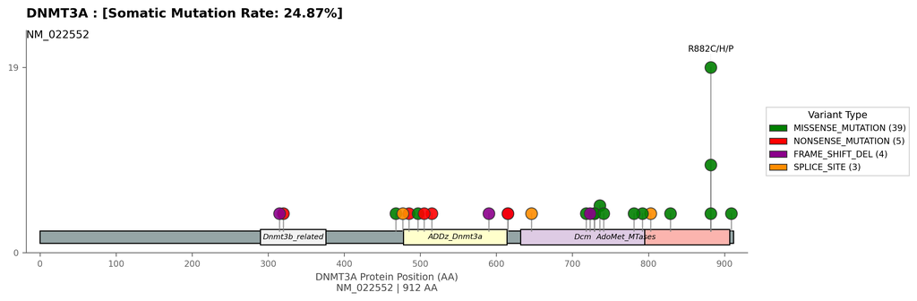

### Show Only Protein Domains

Setting `show_lollipops=False` displays only the protein backbone with PFAM domain annotations, without mutation markers.

```python
py_mutation.lollipop_plot(
    gene='DNMT3A',
    aa_col='Protein_Change',
    transcript_id='NM_022552',
    label_top_n=1,
    show_lollipops=False,
    figsize=(12, 4)
)
```

py_mutation.lollipop_plot( gene='DNMT3A', aa_col='Protein_Change', transcript_id='NM_022552', label_top_n=1, show_lollipops=False, figsize=(12, 4) )

```
2026-10-13 14:45:02,940 | INFO | pyMut.visualizations.lollipop_plot | Protein domain plot for DNMT3A created in 0.55s
```

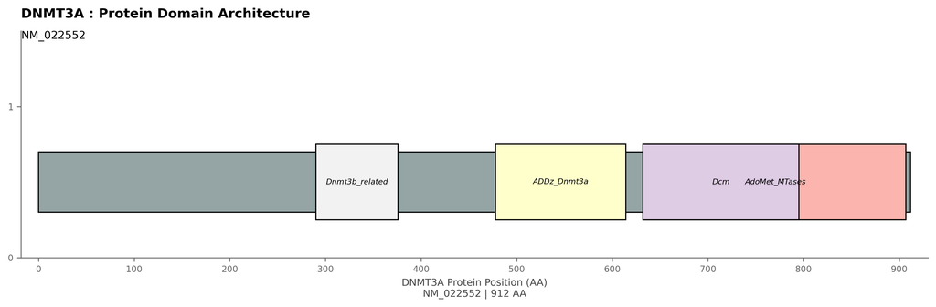

## Lollipop Plot - TP53

TP53 is a tumor suppressor gene frequently mutated across many cancer types. This example demonstrates the same visualization approach with a different gene.

```python
py_mutation.lollipop_plot(
    gene='TP53',
    aa_col='Protein_Change',
    transcript_id='NM_000546',
    label_top_n=1,
    figsize=(12, 4)
)
```

py_mutation.lollipop_plot( gene='TP53', aa_col='Protein_Change', transcript_id='NM_000546', label_top_n=1, figsize=(12, 4) )

```
2026-10-13 14:45:03,692 | INFO | pyMut.visualizations.lollipop_plot | Lollipop plot for TP53 created in 0.59s (19 mutations, 17 AA changes)
```

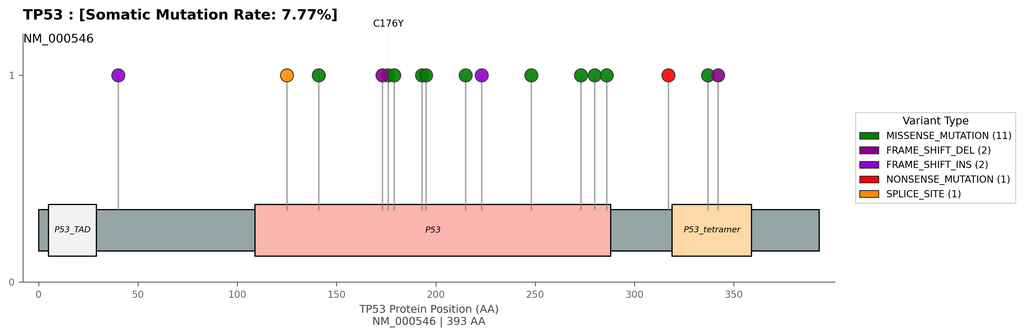

## Label Specific Residue Positions (`label_pos`)

The `label_pos` parameter allows labeling specific protein positions, mirroring `maftools`' `labelPos` parameter. You can pass a single integer position, a list of positions, or `"all"` to label every altered position.

```python
# Specifically label hotspot position 882 in DNMT3A
py_mutation.lollipop_plot(
    gene="DNMT3A",
    aa_col="Protein_Change",
    transcript_id="NM_022552",
    label_pos=882,
    figsize=(12, 4)
)
```

# Specifically label hotspot position 882 in DNMT3A py_mutation.lollipop_plot( gene="DNMT3A", aa_col="Protein_Change", transcript_id="NM_022552", label_pos=882, figsize=(12, 4) )

```
2026-10-13 14:45:04,566 | INFO | pyMut.visualizations.lollipop_plot | Lollipop plot for DNMT3A created in 0.57s (54 mutations, 26 AA changes)
```

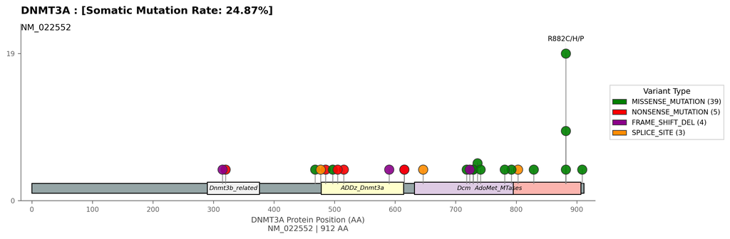

```python
# Specifically label hotspot position 175 in TP53
py_mutation.lollipop_plot(
    gene="TP53",
    aa_col="Protein_Change",
    transcript_id="NM_000546",
    label_pos=175,
    figsize=(12, 4)
)
```

# Specifically label hotspot position 175 in TP53 py_mutation.lollipop_plot( gene="TP53", aa_col="Protein_Change", transcript_id="NM_000546", label_pos=175, figsize=(12, 4) )

```
2026-10-13 14:45:05,390 | WARNING | pyMut.visualizations.lollipop_plot | label_pos [175] doesn't match any mutated position. Mutated positions found: [40, 125, 141, 173, 176, 179, 193, 195, 215, 223, 248, 273, 280, 286, 317, 337, 342]
2026-10-13 14:45:05,467 | INFO | pyMut.visualizations.lollipop_plot | Lollipop plot for TP53 created in 0.57s (19 mutations, 17 AA changes)
```

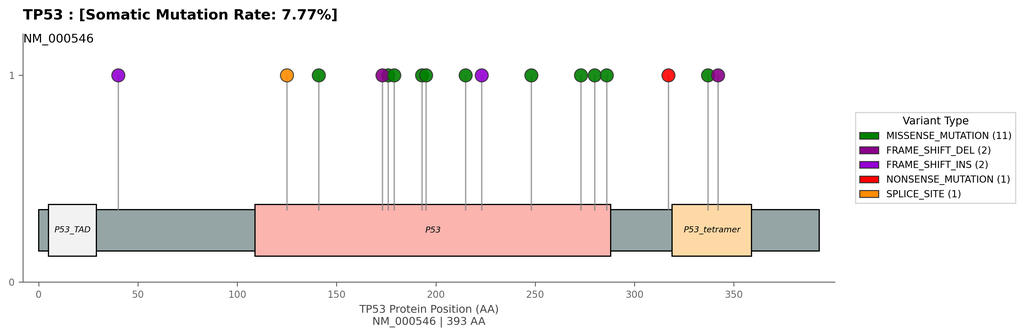